# Tugas Pertemuan 4 MPDW

## 2.4 Plot PACF

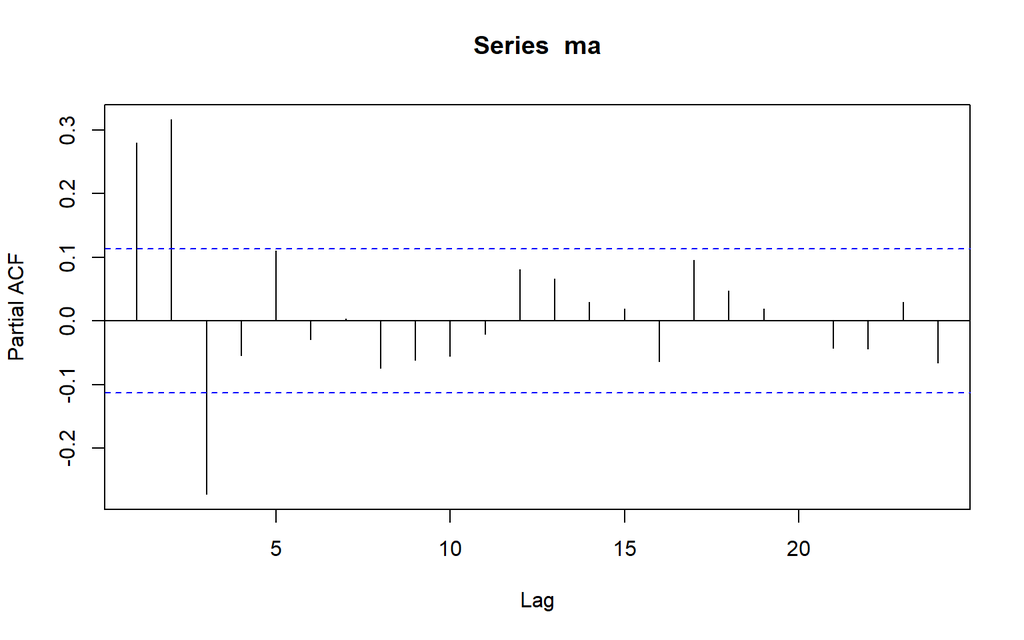

```r
pacf(ma)
```

PACF menunjukkan banyak lag dengan nilai kecil dan cepat menurun, tidak ada cut-off yang jelas. Pola ini sesuai dengan proses MA, karena pada MA(q) biasanya PACF tidak terputus secara tajam (bisa menyerupai “tailing off”). Artinya PACF bukan indikator utama untuk orde MA, tapi mendukung bahwa ini bukan AR murni (karena tidak ada cut-off jelas pada PACF awal). ## Plot EACF

```r
TSA::eacf(ma)
```

```
## AR/MA
##   0 1 2 3 4 5 6 7 8 9 10 11 12 13
## 0 x x o o o o o o o x o  o  o  o
## 1 x x o o o o o o o o o  o  o  o
## 2 x x x x o o o o o o o  o  o  o
## 3 x x x x x o o o o o o  o  o  o
## 4 x x o o x o o o o o o  o  o  o
## 5 x o o o x x x o o o o  o  o  o
## 6 x o x o o o o o o o o  o  o  o
## 7 o x x x o o o o o o o  o  o  o
```

Berdasarkan pola segitiga nol pada plot EACF, terlihat bahwa segitiga nol berada pada ordo AR(0) dan ordo MA(2). ## Scatter Plot Antar Lag

### 2.4.1 Korelasi antara Yt dengan Y(t-1)

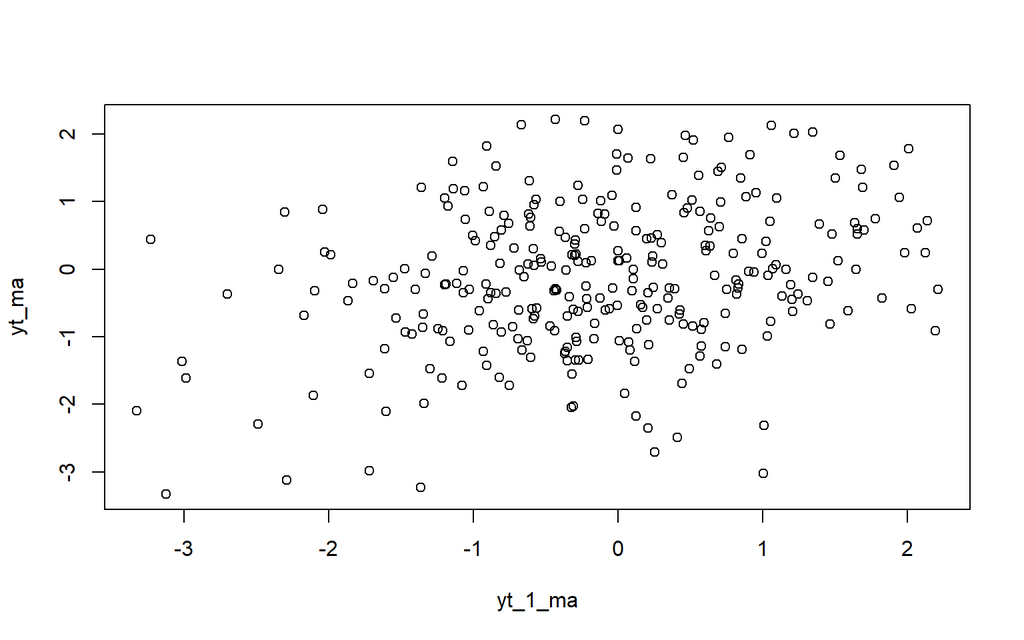

```r
#Yt
yt_ma <- ma[-1]
#Yt-1
yt_1_ma <- ma[-300]
plot(y=yt_ma,x=yt_1_ma)
```

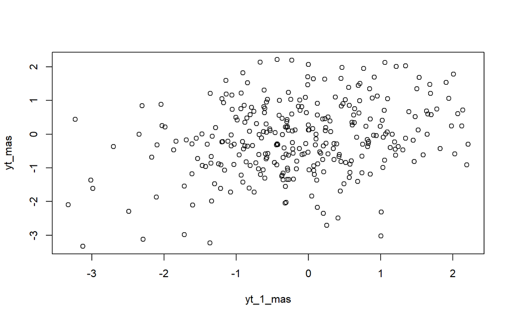

```r
#Arimasim
#Yt
yt_mas <- ma2[-1]
#Yt-1
yt_1_mas <- ma2[-300]
plot(y=yt_mas,x=yt_1_mas)
```